# field_temperature_measures

Fabian C. Salgado-Roa

2024-02-08

# Termal differences black morph vs black-and-white morph in the field

load tidyverse and input with all measures

```r
library(tidyverse)
measures<-read_csv("C:/Users/Fabian C. Salgado/Dropbox/PhD_FabianSalgado/research_proposal/aim2/thermal_photos/2023_ballarat/field_form.csv")
```

Define a function to calculate standard error

```r
se <- function(x) {
  sd(x) / sqrt(length(x))
}
```

This file has dorsal and ventral measures for multiple variables of both black and black-and-white morph. The variables we measured in the field were:

```
wind_v=Ventral wind speed
wind_d=Ventral wind speed
temp_v=Temperature ventral side
temp_d=Temperature ventral side
light_v=Light recieved ventral side
light_d=Light recieved dorsal side
height=Height at which the individual was at time of measure
wind_temp_v=Temperature of wind at time of measure on ventral side
wind_temp_d=Temperature of wind at time of measure on dorsal side
```

We will explore the differences in temperature between morphs per side

## Field Termal differences

We will explore the differences in temperature between morphs per side

### Ventral side

Before running the model let’s explore the correlation between the predictors

Explore a correlation plot

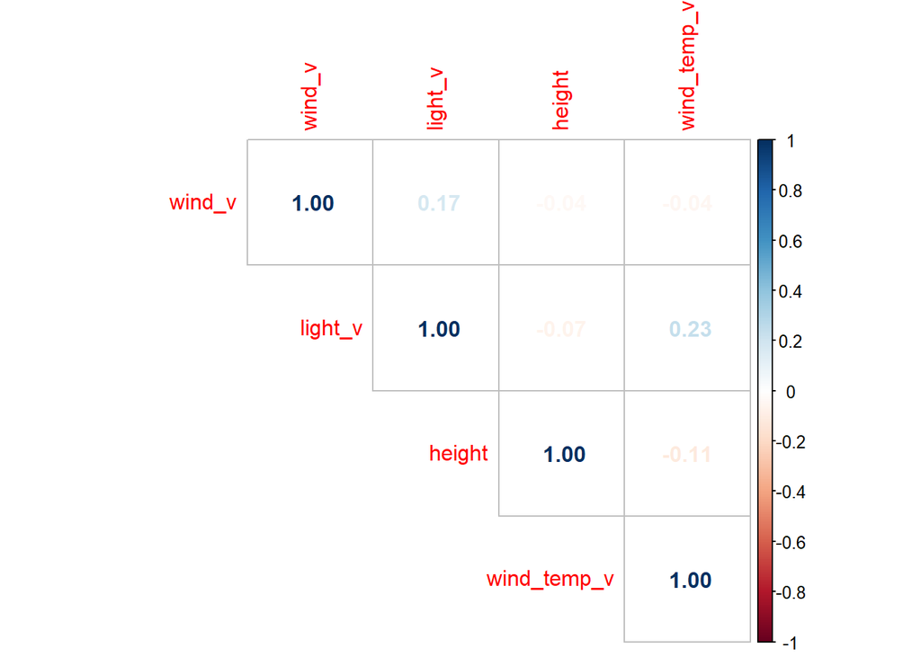

```r
cor_matrix <- cor(na.omit(measures[,c("wind_v","light_v","height","wind_temp_v")]))

colnames(cor_matrix)<-c("wind_v","light_v","height","wind_temp_v")

rownames(cor_matrix)<-c("wind_v","light_v","height","wind_temp_v")

corrplot::corrplot(cor_matrix, method = "number", type = "upper", order = "original", tl.cex=1, )
```

The predictors do not seem to have high correlations

```r
ventral_temp <- lm(temp_v ~ wind_v+light_v+height+wind_temp_v+morph, data=measures)

performance::check_collinearity(ventral_temp)
```

| Term | VIF | VIF_CI_low | VIF_CI_high | SE_factor | Tolerance | Tolerance_CI_low | Tolerance_CI_high |
| --- | --- | --- | --- | --- | --- | --- | --- |
| wind_v | 1.056761 | 1.000334 | 10.635561 | 1.027989 | 0.9462876 | 0.09402418 | 0.9996657 |
| light_v | 1.196761 | 1.030827 | 2.255867 | 1.093966 | 0.8355889 | 0.44328862 | 0.9700947 |
| height | 1.075382 | 1.001387 | 5.096798 | 1.037006 | 0.9299025 | 0.19620163 | 0.9986149 |
| wind_temp_v | 1.077780 | 1.001593 | 4.797929 | 1.038162 | 0.9278329 | 0.20842325 | 0.9984096 |
| morph | 1.152258 | 1.016171 | 2.433612 | 1.073433 | 0.8678612 | 0.41091189 | 0.9840866 |

There is low correlation!!!

Now let’s build the model

```r
ventral_temp <- lm(temp_v ~ wind_v+light_v+height+wind_temp_v+morph, data=measures)
summary(ventral_temp)
```

```
##
## Call:
## lm(formula = temp_v ~ wind_v + light_v + height + wind_temp_v +
##     morph, data = measures)
##
## Residuals:
##      Min       1Q   Median       3Q      Max
## -1.97284 -0.69617 -0.07699  0.84538  3.07758
##
## Coefficients:
##              Estimate Std. Error t value Pr(>|t|)
## (Intercept) 13.964037   4.802853   2.907 0.007724 **
## wind_v      -0.466421   0.233835  -1.995 0.057557 .
## light_v      0.001984   0.001102   1.800 0.084366 .
## height      -0.006173   0.010121  -0.610 0.547681
## wind_temp_v  0.592742   0.154289   3.842 0.000785 ***
## morphwhite   0.077067   0.491925   0.157 0.876820
## ---
## Signif. codes:  0 '***' 0.001 '**' 0.01 '*' 0.05 '.' 0.1 ' ' 1
##
## Residual standard error: 1.255 on 24 degrees of freedom
## Multiple R-squared:  0.5371, Adjusted R-squared:  0.4407
## F-statistic:  5.57 on 5 and 24 DF,  p-value: 0.001523
```

```r
anova(ventral_temp)
```

|  | Df | Sum Sq | Mean Sq | F value | Pr(>F) |
| --- | --- | --- | --- | --- | --- |
| wind_v | 1 | 5.36529099 | 5.36529099 | 3.40630431 | 0.0773206297 |
| light_v | 1 | 13.35575016 | 13.35575016 | 8.47926969 | 0.0076429001 |
| height | 1 | 1.78032313 | 1.78032313 | 1.13028768 | 0.2982947921 |
| wind_temp_v | 1 | 23.32542815 | 23.32542815 | 14.80879723 | 0.0007725376 |
| morph | 1 | 0.03865906 | 0.03865906 | 0.02454378 | 0.8768196735 |
| Residuals | 24 | 37.80254851 | 1.57510619 | NA | NA |

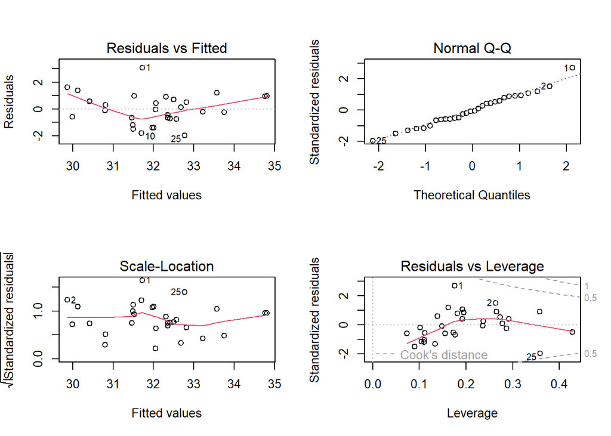

```r
par(mfrow=c(2,2))
plot(ventral_temp)
```

```r
measures$temp_v_predict <- predict(ventral_temp, type = "response")
```

Let’s explore with a graph the significant association

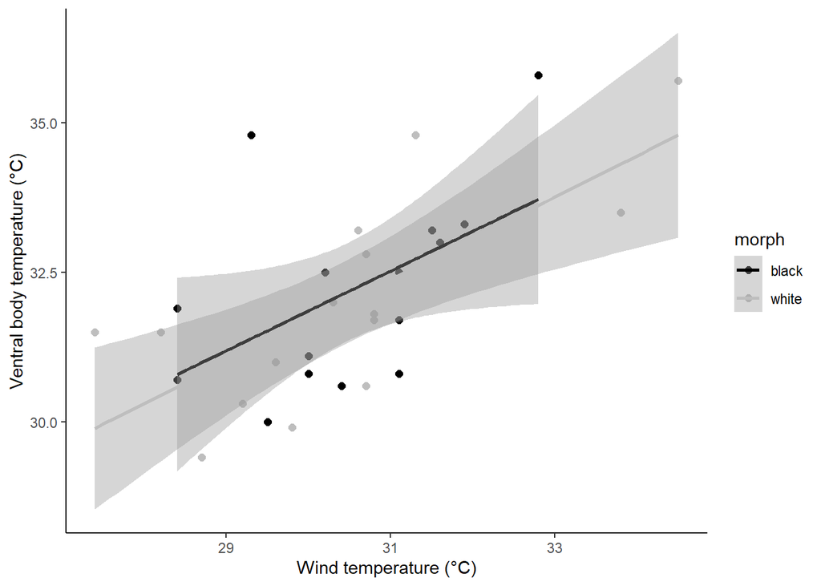

```r
w_col<-"gray"
b_col<-"black"
par(mfrow=c(1,1))
ggplot(data = measures, aes(x = wind_temp_v, y = temp_v, col = morph))+geom_point(size=2)+geom_smooth(method = "lm", se = TRUE)+scale_colour_manual(values = c("black" = b_col,"white" = w_col))+theme_classic()+labs(x="Wind temperature (°C)",y="Ventral body temperature (°C)")
```

Now differences between morphs

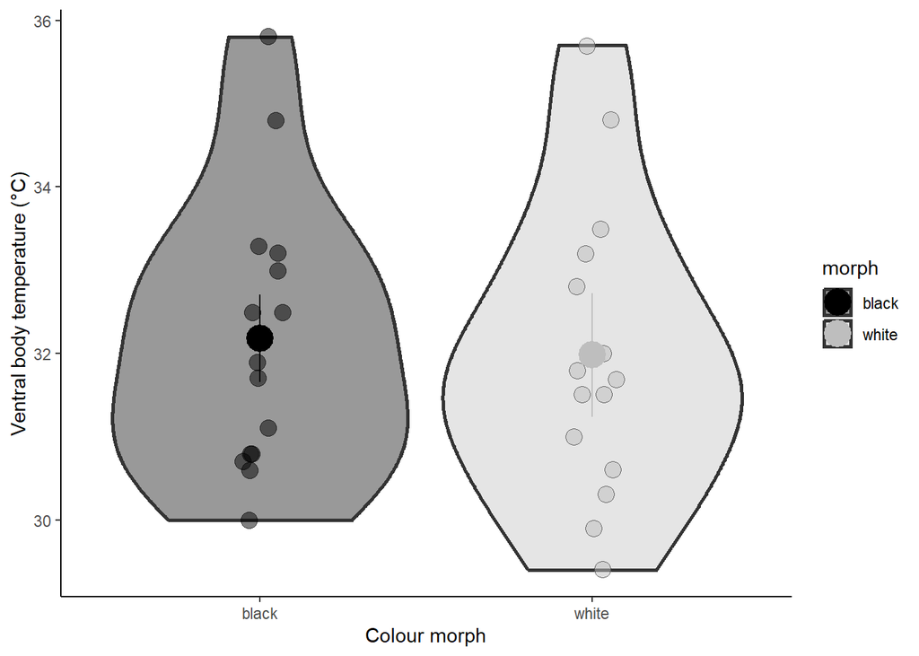

```r
par(mfrow=c(1,1))
w_col<-"gray"
b_col<-"black"
ggplot(data = measures, aes(x = morph, y = temp_v, fill = morph)) +
  scale_fill_viridis_d(option = "D") +
  geom_violin(alpha = 0.4, position = position_dodge(width = .75), size = 1) +
  geom_point(shape = 21, size = 4, position = position_jitterdodge(jitter.width = 0.15, jitter.height = 0.01), alpha = 0.5) +
  scale_fill_manual(values = c("black" = b_col,"white" = w_col))+
  stat_summary(
    fun = mean,
    aes(x = morph, y = temp_v_predict , color = morph, group = morph),
    fun.min = function(x) mean(x) - 2 * se(x),
    fun.max = function(x) mean(x) + 2 * se(x),
    geom = "pointrange",
    position = position_dodge(width = .75),
    size = 1.5
  ) +
  theme_classic()+
  scale_colour_manual(values = c("black" = b_col,"white" = w_col))+labs(x="Colour morph",y="Ventral body temperature (°C)")
```

### Dorsal side

Before running the model let’s explore the correlation between the predictors

Explore a correlation plot

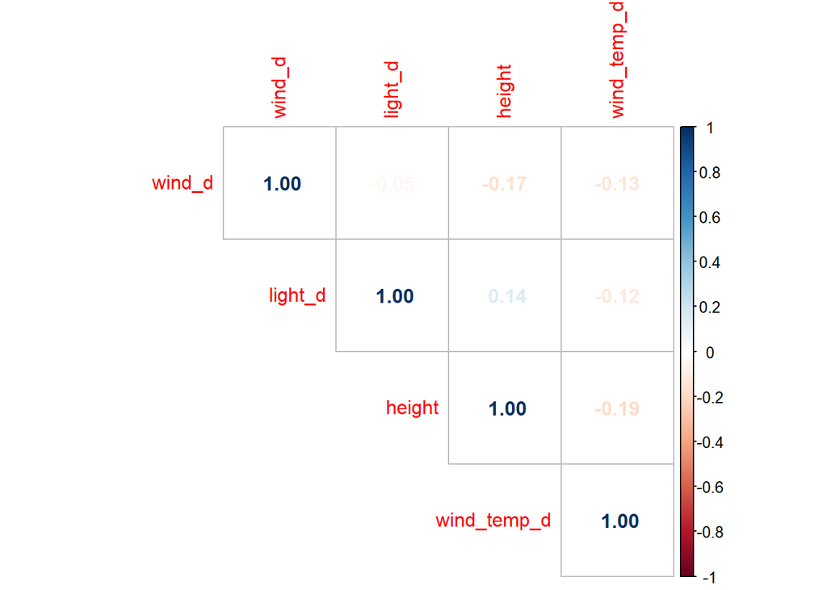

```r
cor_matrix <- cor(na.omit(measures[,c("wind_d","light_d","height","wind_temp_d")]))

colnames(cor_matrix)<-c("wind_d","light_d","height","wind_temp_d")

rownames(cor_matrix)<-c("wind_d","light_d","height","wind_temp_d")

corrplot::corrplot(cor_matrix, method = "number", type = "upper", order = "original", tl.cex=1, )
```

The predictors do not seem to have high correlations

```r
dorsal_temp <- lm(temp_d ~ wind_d+light_d+height+wind_temp_d+morph, data=measures)

performance::check_collinearity(dorsal_temp)
```

| Term | VIF | VIF_CI_low | VIF_CI_high | SE_factor | Tolerance | Tolerance_CI_low | Tolerance_CI_high |
| --- | --- | --- | --- | --- | --- | --- | --- |
| wind_d | 1.272134 | 1.061628 | 2.201678 | 1.127889 | 0.7860809 | 0.4541990 | 0.9419497 |
| light_d | 1.193452 | 1.029627 | 2.263162 | 1.092452 | 0.8379057 | 0.4418597 | 0.9712256 |
| height | 1.137585 | 1.012165 | 2.556102 | 1.066576 | 0.8790555 | 0.3912207 | 0.9879815 |
| wind_temp_d | 1.087956 | 1.002659 | 3.909915 | 1.043051 | 0.9191550 | 0.2557600 | 0.9973485 |
| morph | 1.406080 | 1.126293 | 2.305707 | 1.185783 | 0.7111969 | 0.4337064 | 0.8878686 |

There is low correlation!!!

Now let’s build the model

```r
dorsal_temp <- lm(temp_d ~ wind_d+light_d+height+wind_temp_d+morph, data=measures)
summary(dorsal_temp)
```

```
##
## Call:
## lm(formula = temp_d ~ wind_d + light_d + height + wind_temp_d +
##     morph, data = measures)
##
## Residuals:
##     Min      1Q  Median      3Q     Max
## -3.4498 -1.0779 -0.1254  0.8750  2.5667
##
## Coefficients:
##               Estimate Std. Error t value Pr(>|t|)
## (Intercept) 13.0005720  6.4784557   2.007  0.05617 .
## wind_d      -0.5933802  0.2826290  -2.100  0.04647 *
## light_d      0.0002011  0.0061929   0.032  0.97436
## height       0.0080297  0.0132479   0.606  0.55013
## wind_temp_d  0.5993319  0.2012764   2.978  0.00654 **
## morphwhite  -0.4856648  0.6915722  -0.702  0.48927
## ---
## Signif. codes:  0 '***' 0.001 '**' 0.01 '*' 0.05 '.' 0.1 ' ' 1
##
## Residual standard error: 1.597 on 24 degrees of freedom
## Multiple R-squared:  0.4507, Adjusted R-squared:  0.3363
## F-statistic: 3.938 on 5 and 24 DF,  p-value: 0.009493
```

```r
anova(dorsal_temp)
```

|  | Df | Sum Sq | Mean Sq | F value | Pr(>F) |
| --- | --- | --- | --- | --- | --- |
| wind_d | 1 | 26.41248804 | 26.41248804 | 10.35340372 | 0.003679735 |
| light_d | 1 | 0.68848495 | 0.68848495 | 0.26987850 | 0.608171671 |
| height | 1 | 0.08850604 | 0.08850604 | 0.03469339 | 0.853805029 |
| wind_temp_d | 1 | 21.78918000 | 21.78918000 | 8.54111801 | 0.007454467 |
| morph | 1 | 1.25812686 | 1.25812686 | 0.49317184 | 0.489271398 |
| Residuals | 24 | 61.22621412 | 2.55109226 | NA | NA |

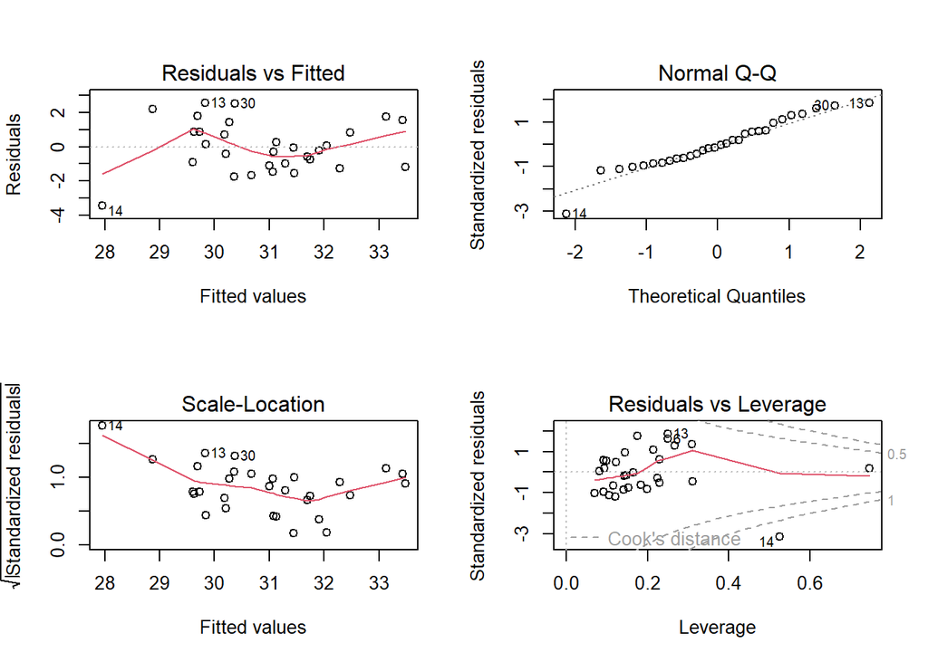

```r
par(mfrow=c(2,2))
plot(dorsal_temp)
```

No differences between morphs. The body temperature is correlated with the wind temperature and wind speed

```r
measures$temp_d_predict <- predict(dorsal_temp, type = "response")
```

Let’s explore with a graph the significant association

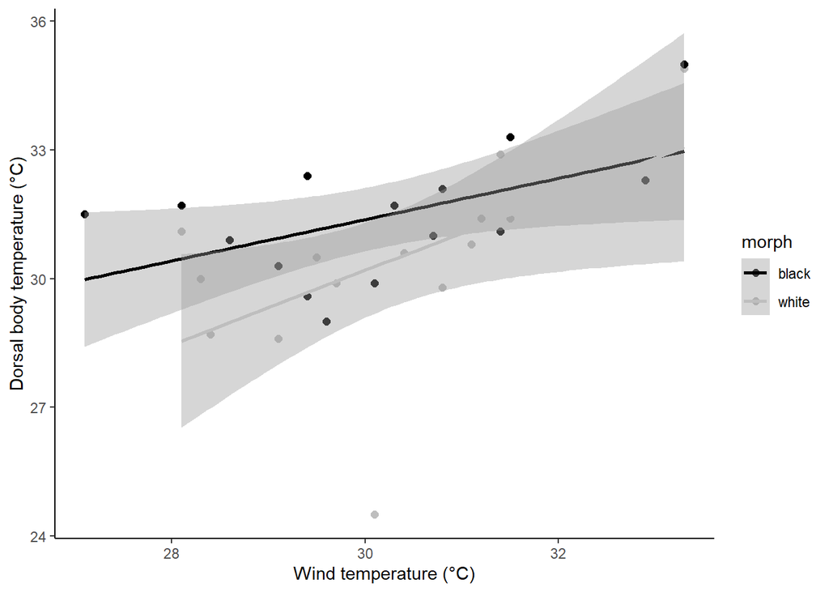

```r
par(mfrow=c(1,1))
ggplot(data = measures, aes(x = wind_temp_d, y = temp_d, col = morph))+geom_point(size=2)+geom_smooth(method = "lm", se = TRUE)+scale_colour_manual(values = c("black" = b_col,"white" = w_col))+theme_classic()+labs(x="Wind temperature (°C)",y="Dorsal body temperature (°C)")
```

Now differences between morphs

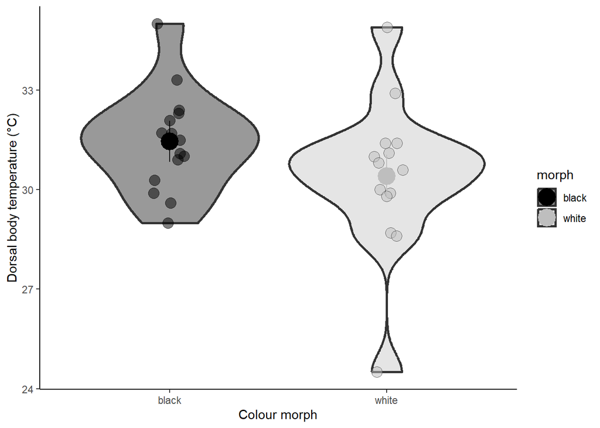

```r
par(mfrow=c(1,1))
w_col<-"gray"
b_col<-"black"
ggplot(data = measures, aes(x = morph, y = temp_d, fill = morph)) +
  scale_fill_viridis_d(option = "D") +
  geom_violin(alpha = 0.4, position = position_dodge(width = .75), size = 1) +
  geom_point(shape = 21, size = 4, position = position_jitterdodge(jitter.width = 0.15, jitter.height = 0.01), alpha = 0.5) +
  scale_fill_manual(values = c("black" = b_col,"white" = w_col))+
  stat_summary(
    fun = mean,
    aes(x = morph, y = temp_d_predict , color = morph, group = morph),
    fun.min = function(x) mean(x) - 2 * se(x),
    fun.max = function(x) mean(x) + 2 * se(x),
    geom = "pointrange",
    position = position_dodge(width = .75),
    size = 1.5
  ) +
  theme_classic()+
  scale_colour_manual(values = c("black" = b_col,"white" = w_col))+labs(x="Colour morph",y="Dorsal body temperature (°C)")
```